[figure not shown]

# Projeto Final Inferência e Análise de Regressão

Matheus Ramos Esteves

2023-12-01

# 1 Motivação

Este projeto tem por finalidade realizar uma regressão linear múltipla, e encontrar o melhor modelo possível para a mesma e assim aplicar os conceitos aprendidos em aula durante o segundo semestre de 2023, na turma de IAR (Inferência e Análise de Regressão), ministrada pela Profa. Dra. Flávia cristina Martins Queiroz Mariano.

# 2 Dados utilizados

O conjunto de dados escolhido são referentes aos da temporada 2022-2023 da NBA (*National Basketball Association*), que contém informações referentes a todos os jogadores da liga, como:

- Total de pontos feito pelo jogador na temporada;
- Idade do jogador;
- Time que joga;
- Quantidade de bloqueios do jogador;
- Quantidade de *turnovers* do jogador;
- Quantidade de lances livres do jogador;
- Quantidade de jogos jogados;
- Quantidade de faltas cometidas;

Tanto a base de dados para download, quanto mais informações sobre a mesma, podem ser encontradas no link a seguir: [Link da Base de Dados](https://www.kaggle.com/datasets/amirhosseinmirzaie/nba-players-stats2023-season).

Para este trabalho, a variável dependente (Y) que será utilizada será o *fantasy point* (FP) do jogador, que significa uma pontuação do jogador, não em relação a quantidade de cestas apenas, mas como um *score* individual, que é cumulativo durante todo o campeonato. Dessa forma o projeto é baseado em encontrar o melhor modelo possível para prever qual seria o FP de um jogador da liga, com base nas variáveis encontradas para explicar o FP.

# 3 Importação dos dados

## 3.1 Carregando pacotes que serão necessários para a realização do projeto

```r
library(MASS)
library(tidyverse)
library(car)
library(ggplot2)
library(gridExtra)
library(lmtest)
library(knitr)
library(rmarkdown)
library(htmltools)
```

## 3.2 Transformando o arquivo de dados em dataset e visualizando os dados

```r
dataset <- "C:/Users/mathe/Documents/Unifesp/Materias/IAR/Trabalho final/2023_nba_player_stats.csv"
data <- read.csv(dataset, sep = ",")

glimpse(data)
```

```
## Rows: 539
## Columns: 30
## $ PName <chr> "Jayson Tatum", "Joel Embiid", "Luka Doncic", "Shai Gilgeous-Ale…
## $ POS   <chr> "SF", "C", "PG", "PG", "PF", "SG", "PF", "SG", "PG", "SG", "PG",…
## $ Team  <chr> "BOS", "PHI", "DAL", "OKC", "MIL", "MIN", "NYK", "CLE", "ATL", "…
## $ Age   <int> 25, 29, 24, 24, 28, 21, 28, 26, 24, 28, 32, 25, 33, 26, 29, 25, …
## $ GP    <int> 74, 66, 66, 68, 63, 79, 77, 68, 73, 77, 58, 73, 74, 67, 71, 66, …
## $ W     <int> 52, 43, 33, 33, 47, 40, 44, 44, 38, 38, 27, 44, 37, 46, 35, 32, …
## $ L     <int> 22, 23, 33, 35, 16, 39, 33, 24, 35, 39, 31, 29, 37, 21, 36, 34, …
## $ Min   <dbl> 2732.2, 2284.1, 2390.5, 2416.0, 2023.6, 2841.5, 2737.3, 2432.4, …
## $ PTS   <int> 2225, 2183, 2138, 2135, 1959, 1946, 1936, 1922, 1914, 1913, 1866…
## $ FGM   <int> 727, 728, 719, 704, 707, 707, 658, 679, 597, 673, 556, 682, 657,…
## $ FGA   <int> 1559, 1328, 1449, 1381, 1278, 1541, 1432, 1402, 1390, 1388, 1202…
## $ FG.   <dbl> 46.6, 54.8, 49.6, 51.0, 55.3, 45.9, 45.9, 48.4, 42.9, 48.5, 46.3…
## $ X3PM  <int> 240, 66, 185, 58, 47, 213, 218, 245, 154, 204, 244, 119, 46, 163…
```

[output cut: 17 more lines]

```r
paged_table(data)
```

| PName | POS | Team | Age | GP | W | L | Min | PTS | FGM | FGA | FG. | X3PM | X3PA | X3P. | FTM | FTA | FT. | OREB | DREB | REB | AST | TOV | STL | BLK | PF | FP | DD2 | TD3 | X... |
| --- | --- | --- | --- | --- | --- | --- | --- | --- | --- | --- | --- | --- | --- | --- | --- | --- | --- | --- | --- | --- | --- | --- | --- | --- | --- | --- | --- | --- | --- |
| Jayson Tatum | SF | BOS | 25 | 74 | 52 | 22 | 2732.2 | 2225 | 727 | 1559 | 46.6 | 240 | 686 | 35.0 | 531 | 622 | 85.4 | 78 | 571 | 649 | 342 | 213 | 78 | 51 | 160 | 3691 | 31 | 1 | 470 |
| Joel Embiid | C | PHI | 29 | 66 | 43 | 23 | 2284.1 | 2183 | 728 | 1328 | 54.8 | 66 | 200 | 33.0 | 661 | 771 | 85.7 | 113 | 557 | 670 | 274 | 226 | 66 | 112 | 205 | 3706 | 39 | 1 | 424 |
| Luka Doncic | PG | DAL | 24 | 66 | 33 | 33 | 2390.5 | 2138 | 719 | 1449 | 49.6 | 185 | 541 | 34.2 | 515 | 694 | 74.2 | 54 | 515 | 569 | 529 | 236 | 90 | 33 | 166 | 3747 | 36 | 10 | 128 |
| Shai Gilgeous-Alexander | PG | OKC | 24 | 68 | 33 | 35 | 2416.0 | 2135 | 704 | 1381 | 51.0 | 58 | 168 | 34.5 | 669 | 739 | 90.5 | 59 | 270 | 329 | 371 | 192 | 112 | 65 | 192 | 3425 | 3 | 0 | 149 |
| Giannis Antetokounmpo | PF | MIL | 28 | 63 | 47 | 16 | 2023.6 | 1959 | 707 | 1278 | 55.3 | 47 | 171 | 27.5 | 498 | 772 | 64.5 | 137 | 605 | 742 | 359 | 246 | 52 | 51 | 197 | 3451 | 46 | 6 | 341 |
| Anthony Edwards | SG | MIN | 21 | 79 | 40 | 39 | 2841.5 | 1946 | 707 | 1541 | 45.9 | 213 | 578 | 36.9 | 319 | 422 | 75.6 | 47 | 411 | 458 | 350 | 259 | 125 | 58 | 186 | 3311 | 9 | 0 | 97 |
| Julius Randle | PF | NYK | 28 | 77 | 44 | 33 | 2737.3 | 1936 | 658 | 1432 | 45.9 | 218 | 636 | 34.3 | 402 | 531 | 75.7 | 141 | 626 | 767 | 316 | 216 | 49 | 21 | 233 | 3324 | 40 | 0 | 170 |
| Donovan Mitchell | SG | CLE | 26 | 68 | 44 | 24 | 2432.4 | 1922 | 679 | 1402 | 48.4 | 245 | 635 | 38.6 | 319 | 368 | 86.7 | 63 | 226 | 289 | 301 | 180 | 99 | 27 | 168 | 2918 | 5 | 0 | 338 |
| Trae Young | PG | ATL | 24 | 73 | 38 | 35 | 2540.7 | 1914 | 597 | 1390 | 42.9 | 154 | 460 | 33.5 | 566 | 639 | 88.6 | 56 | 161 | 217 | 741 | 300 | 80 | 9 | 104 | 3253 | 40 | 0 | 100 |
| Zach LaVine | SG | CHI | 28 | 77 | 38 | 39 | 2767.9 | 1913 | 673 | 1388 | 48.5 | 204 | 544 | 37.5 | 363 | 428 | 84.8 | 42 | 303 | 345 | 327 | 194 | 69 | 18 | 159 | 2885 | 2 | 0 | 18 |

[output cut: 529 more lines]

O banco possui informações de todos os 539 jogadores da NBA e 29 variáveis associadas para cada um, relacionada as estatísticas do player na temporada de 2022-2023, além do nome.

## 3.3 Separação das variáveis do dataset

```r
Pname <- data$PName
POS <- data$POS
Team <- data$Team
Age <- data$Age
GP <- data$GP
W <- data$W
L <- data$L
Min <- data$Min
PTS <- data$PTS
FGM <- data$FGM
FGA <- data$FGA
FG <- data$FG.
X3PM <- data$X3PM
X3PA <- data$X3PA
X3P <- data$X3P.
FTM <- data$FTM
FTA <- data$FTA
FT <- data$FT.
OREB <- data$OREB
DREB <- data$DREB
REB <- data$REB
AST <- data$AST
TOV <- data$TOV
STL <- data$STL
BLK <- data$BLK
PF <- data$PF
FP <- data$FP
DD2 <- data$DD2
TD3 <- data$TD3
X <- data$X
```

# 4 Análise visual dos dados

Fazendo o plot de algumas variáveis em relação ao *fantasy point*, para verificar de maneira visual algumas variáveis que apresentem não ter relação direta com a variável dependente.

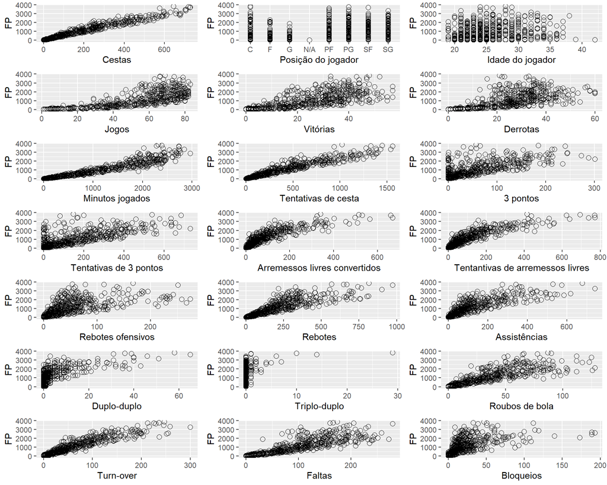

Com isso, pode-se notar que a posição do jogador e a idade, a quantidade de duplos-duplos e triplos-duplos parecem não ter relação diretas com os *fantasy points* do jogador.

# 5 Modelos de regressão

Partimos agora para buscar o melhor modelo para tentar explicar nossa variável dependente. Uma primeira tentativa é utizar todas as variáveis para termos de onde começar a fase de testes. Dessa forma, utilizaremos todas as variáveis para observar os resultados obtidos

## 5.1 Primeiro teste

```r
first_model <- lm(FP ~ GP + W + PTS+ FGM + FGA +
                  FG + X3PM + X3PA + X3P + FTM +
                  FTA + FT + OREB + DREB + REB +
                  AST + TOV + STL + BLK + PF +
                  FP, data = data)

summary(first_model)
```

```
##
## Call:
## lm(formula = FP ~ GP + W + PTS + FGM + FGA + FG + X3PM + X3PA +
##     X3P + FTM + FTA + FT + OREB + DREB + REB + AST + TOV + STL +
##     BLK + PF + FP, data = data)
##
## Residuals:
##      Min       1Q   Median       3Q      Max
## -0.54939 -0.25112  0.00488  0.24413  0.51420
##
## Coefficients: (2 not defined because of singularities)
##               Estimate Std. Error   t value Pr(>|t|)
## (Intercept) -7.778e-03  7.595e-02    -0.102    0.918
## GP          -1.476e-03  1.583e-03    -0.933    0.351
## W            2.710e-03  2.073e-03     1.307    0.192
## PTS          9.993e-01  1.171e-03   853.649   <2e-16 ***
## FGM          1.432e-03  2.509e-03     0.571    0.568
## FGA         -1.303e-04  5.199e-04    -0.251    0.802
## FG           1.510e-03  1.438e-03     1.050    0.294
## X3PM        -3.058e-05  2.659e-03    -0.012    0.991
## X3PA         7.472e-04  9.815e-04     0.761    0.447
## X3P          6.912e-04  1.054e-03     0.656    0.512
## FTM                 NA         NA        NA       NA
## FTA          8.117e-04  9.951e-04     0.816    0.415
## FT          -9.793e-05  6.808e-04    -0.144    0.886
## OREB         1.201e+00  5.938e-04  2022.647   <2e-16 ***
## DREB         1.200e+00  2.768e-04  4333.404   <2e-16 ***
## REB                 NA         NA        NA       NA
## AST          1.500e+00  2.553e-04  5875.644   <2e-16 ***
## TOV         -1.000e+00  8.515e-04 -1174.613   <2e-16 ***
## STL          3.000e+00  9.602e-04  3123.935   <2e-16 ***
## BLK          3.000e+00  7.925e-04  3786.087   <2e-16 ***
## PF          -5.696e-04  5.399e-04    -1.055    0.292
## ---
## Signif. codes:  0 '***' 0.001 '**' 0.01 '*' 0.05 '.' 0.1 ' ' 1
##
## Residual standard error: 0.2928 on 520 degrees of freedom
## Multiple R-squared:      1,  Adjusted R-squared:      1
## F-statistic: 2.786e+08 on 18 and 520 DF,  p-value: < 2.2e-16
```

Com isso, foi possível observar um R<sup>2</sup> de 100%, o que apesar de parecer bom, é passivo de dúvidas, pois pode haver multicolinearidade nos dados. Entretanto, muitas variáveis não apresentaram significância no modelo, irá ser utilizado o `stepAIC()` para encontrar um modelo mais ajustado para o problema.

```r
stepAIC(first_model, direction = "both")
```

```
## Start:  AIC=-1305.24
## FP ~ GP + W + PTS + FGM + FGA + FG + X3PM + X3PA + X3P + FTM +
##     FTA + FT + OREB + DREB + REB + AST + TOV + STL + BLK + PF +
##     FP
##
##
## Step:  AIC=-1305.24
## FP ~ GP + W + PTS + FGM + FGA + FG + X3PM + X3PA + X3P + FTM +
##     FTA + FT + OREB + DREB + REB + AST + TOV + STL + BLK + PF
##
##
## Step:  AIC=-1305.24
## FP ~ GP + W + PTS + FGM + FGA + FG + X3PM + X3PA + X3P + FTM +
##     FTA + FT + OREB + DREB + AST + TOV + STL + BLK + PF
##
##
## Step:  AIC=-1305.24
## FP ~ GP + W + PTS + FGM + FGA + FG + X3PM + X3PA + X3P + FTA +
##     FT + OREB + DREB + AST + TOV + STL + BLK + PF
##
##        Df Sum of Sq     RSS     AIC
## - X3PM  1         0      45 -1307.2
## - FT    1         0      45 -1307.2
## - FGA   1         0      45 -1307.2
## - FGM   1         0      45 -1306.9
## - X3P   1         0      45 -1306.8
## - X3PA  1         0      45 -1306.6
## - FTA   1         0      45 -1306.6
## - GP    1         0      45 -1306.3
## - FG    1         0      45 -1306.1
## - PF    1         0      45 -1306.1
## - W     1         0      45 -1305.5
## <none>                   45 -1305.2
## - PTS   1     62494   62538  2598.3
## - TOV   1    118323  118367  2942.2
## - OREB  1    350848  350892  3527.9
## - STL   1    836917  836961  3996.5
## - BLK   1   1229305 1229350  4203.7
## - DREB  1   1610411 1610455  4349.2
## - AST   1   2960665 2960709  4677.4
```

[output cut: 243 more lines]

```
## + FTA   1         0       45 -1317.2
## + FGM   1         0       45 -1316.9
## + FTM   1         0       45 -1316.8
## + W     1         0       45 -1316.8
## + X3P   1         0       45 -1316.8
## + GP    1         0       45 -1316.6
## + FT    1         0       45 -1316.5
## + X3PM  1         0       45 -1316.4
## - TOV   1    151828   151873  3056.5
## - OREB  1    427715   427760  3614.7
## - STL   1   1045904  1045949  4096.6
## - BLK   1   1378989  1379034  4245.6
## - DREB  1   1879285  1879330  4412.5
## - AST   1   3224748  3224793  4703.5
## - PTS   1  11269824 11269869  5377.9
```

```
##
## Call:
## lm(formula = FP ~ PTS + X3PA + OREB + DREB + AST + TOV + STL +
##     BLK, data = data)
##
## Coefficients:
## (Intercept)          PTS         X3PA         OREB         DREB          AST
##   0.0605561    1.0000420    0.0002367    1.2008375    1.1996273    1.5001085
##         TOV          STL          BLK
##  -1.0005360    2.9988904    3.0003412
```

## 5.2 Segundo teste

Como pode ser visto no passo anterior, um modelo melhor para ser utilizado é

```r
second_model <- lm(FP ~ PTS + X3PA + OREB + DREB + AST + TOV + STL +
                    BLK, data = data)

summary(second_model)
```

```
##
## Call:
## lm(formula = FP ~ PTS + X3PA + OREB + DREB + AST + TOV + STL +
##     BLK, data = data)
##
## Residuals:
##      Min       1Q   Median       3Q      Max
## -0.49288 -0.26134 -0.00109  0.24175  0.51034
##
## Coefficients:
##               Estimate Std. Error   t value Pr(>|t|)
## (Intercept)  6.056e-02  2.094e-02     2.892  0.00398 **
## PTS          1.000e+00  8.696e-05 11499.633  < 2e-16 ***
## X3PA         2.367e-04  1.583e-04     1.495  0.13551
## OREB         1.201e+00  5.360e-04  2240.282  < 2e-16 ***
## DREB         1.200e+00  2.555e-04  4695.931  < 2e-16 ***
## AST          1.500e+00  2.439e-04  6151.391  < 2e-16 ***
## TOV         -1.001e+00  7.496e-04 -1334.754  < 2e-16 ***
## STL          2.999e+00  8.560e-04  3503.251  < 2e-16 ***
## BLK          3.000e+00  7.459e-04  4022.591  < 2e-16 ***
## ---
## Signif. codes:  0 '***' 0.001 '**' 0.01 '*' 0.05 '.' 0.1 ' ' 1
##
## Residual standard error: 0.2919 on 530 degrees of freedom
## Multiple R-squared:      1,  Adjusted R-squared:      1
## F-statistic: 6.308e+08 on 8 and 530 DF,  p-value: < 2.2e-16
```

Neste modelo é possível notar que as variáveis se tornam mais significativas para o modelo, mas ainda há uma sem significância, tentaremos então mais um `stepAIC()`, para verificar se há mais variáveis que podem ser retiradas.

```r
stepAIC(second_model, direction = "both")
```

```
## Start:  AIC=-1318.36
## FP ~ PTS + X3PA + OREB + DREB + AST + TOV + STL + BLK
##
##        Df Sum of Sq      RSS     AIC
## <none>                    45 -1318.4
## - X3PA  1         0       45 -1318.1
## - TOV   1    151828   151873  3056.5
## - OREB  1    427715   427760  3614.7
## - STL   1   1045904  1045949  4096.6
## - BLK   1   1378989  1379034  4245.6
## - DREB  1   1879285  1879330  4412.5
## - AST   1   3224748  3224793  4703.5
## - PTS   1  11269824 11269869  5377.9
```

```
##
## Call:
## lm(formula = FP ~ PTS + X3PA + OREB + DREB + AST + TOV + STL +
##     BLK, data = data)
##
## Coefficients:
## (Intercept)          PTS         X3PA         OREB         DREB          AST
##   0.0605561    1.0000420    0.0002367    1.2008375    1.1996273    1.5001085
##         TOV          STL          BLK
##  -1.0005360    2.9988904    3.0003412
```

## 5.3 Terceiro teste

Como no segundo teste o `stepAIC()` não removeu uma variável não significativa do modelo, retiraremos manualmente.

```r
third_model <- lm(FP ~ PTS + OREB + DREB + AST + TOV + STL +
                  BLK, data = data)

summary(third_model)
```

```
##
## Call:
## lm(formula = FP ~ PTS + OREB + DREB + AST + TOV + STL + BLK,
##     data = data)
##
## Residuals:
##      Min       1Q   Median       3Q      Max
## -0.49763 -0.26277  0.00102  0.24086  0.50423
##
## Coefficients:
##               Estimate Std. Error   t value Pr(>|t|)
## (Intercept)  0.0682998  0.0203112     3.363 0.000828 ***
## PTS          1.0001121  0.0000733 13643.963  < 2e-16 ***
## OREB         1.2005281  0.0004950  2425.122  < 2e-16 ***
## DREB         1.1996784  0.0002535  4733.144  < 2e-16 ***
## AST          1.5000666  0.0002425  6185.195  < 2e-16 ***
## TOV         -1.0006448  0.0007469 -1339.686  < 2e-16 ***
## STL          2.9993205  0.0008072  3715.787  < 2e-16 ***
## BLK          3.0001886  0.0007397  4055.878  < 2e-16 ***
## ---
## Signif. codes:  0 '***' 0.001 '**' 0.01 '*' 0.05 '.' 0.1 ' ' 1
##
## Residual standard error: 0.2923 on 531 degrees of freedom
## Multiple R-squared:      1,  Adjusted R-squared:      1
## F-statistic: 7.193e+08 on 7 and 531 DF,  p-value: < 2.2e-16
```

Neste teste todas as variáveis utilizadas foram significativas para o modelo, entretanto ambos R<sup>2</sup> estão altos demais, o que indica que o modelo possui multicolinearidade nas variáveis explicativas, logo será verificado o VIF (Fator de Inflação de Variância)

```r
vif(third_model)
```

```
##       PTS      OREB      DREB       AST       TOV       STL       BLK
##  8.395494  4.192761  7.631762  6.220196 11.934523  3.295097  2.425499
```

Como evidenciado pelo VIF, algumas variáveis possuem valores muito altos de multicolinearidade, como TOV, AST, DREB e PTS. Dado que o número de *turnovers* é o que possui maior valor, logo ele está sendo redundante cm outra variável que está no modelo, então pode ser retirado sem haver perda de informações.

## 5.4 Quarto teste

Retirando a variável TOV do modelo, obtemos:

```r
fourth_model <- lm(FP ~ PTS + OREB + DREB + AST + STL +
                  BLK, data = data)

summary(fourth_model)
```

```
##
## Call:
## lm(formula = FP ~ PTS + OREB + DREB + AST + STL + BLK, data = data)
##
## Residuals:
##     Min      1Q  Median      3Q     Max
## -79.830  -6.764   1.188   6.457  63.898
##
## Coefficients:
##              Estimate Std. Error t value Pr(>|t|)
## (Intercept) -1.975305   1.176571  -1.679   0.0938 .
## PTS          0.942316   0.003443 273.728   <2e-16 ***
## OREB         1.144180   0.028653  39.932   <2e-16 ***
## DREB         1.156817   0.014606  79.200   <2e-16 ***
## AST          1.293088   0.010860 119.069   <2e-16 ***
## STL          3.127896   0.046558  67.183   <2e-16 ***
## BLK          2.987612   0.042968  69.532   <2e-16 ***
## ---
## Signif. codes:  0 '***' 0.001 '**' 0.01 '*' 0.05 '.' 0.1 ' ' 1
##
## Residual standard error: 16.98 on 532 degrees of freedom
## Multiple R-squared:  0.9996, Adjusted R-squared:  0.9996
## F-statistic: 2.486e+05 on 6 and 532 DF,  p-value: < 2.2e-16
```

Houve uma pequena diminuição nos valores de R<sup>2</sup> e do R<sup>2</sup> ajustado, mas novamente será testada a multicolinearidade das variáveis que ficaram.

```r
vif(fourth_model)
```

```
##      PTS     OREB     DREB      AST      STL      BLK
## 5.487332 4.162494 7.510166 3.695922 3.248514 2.425109
```

## 5.5 Quinto teste

O modelo sem ‘DREB’ fica:

```r
fifth_model <- lm(FP ~ PTS + OREB + AST + STL +
                  BLK, data = data)

summary(fifth_model)
```

```
##
## Call:
## lm(formula = FP ~ PTS + OREB + AST + STL + BLK, data = data)
##
## Residuals:
##     Min      1Q  Median      3Q     Max
## -298.32  -20.96   -4.31   19.38  383.28
##
## Coefficients:
##             Estimate Std. Error t value Pr(>|t|)
## (Intercept)  4.55198    4.19362   1.085    0.278
## PTS          1.09144    0.01030 105.993   <2e-16 ***
## OREB         2.65223    0.07651  34.667   <2e-16 ***
## AST          1.41538    0.03841  36.850   <2e-16 ***
## STL          2.85068    0.16588  17.185   <2e-16 ***
## BLK          3.59690    0.15104  23.814   <2e-16 ***
## ---
## Signif. codes:  0 '***' 0.001 '**' 0.01 '*' 0.05 '.' 0.1 ' ' 1
##
## Residual standard error: 60.66 on 533 degrees of freedom
## Multiple R-squared:  0.9954, Adjusted R-squared:  0.9954
## F-statistic: 2.327e+04 on 5 and 533 DF,  p-value: < 2.2e-16
```

Testanto o vif mais uma vez, para analisar se a multicolinearidade deixou de existir:

```r
vif(fifth_model)
```

```
##      PTS     OREB      AST      STL      BLK
## 3.845730 2.324354 3.621201 3.230153 2.347368
```

Dessa vez sim, agora as variáveis não possuem multicolinearidades e o valor de R<sup>2</sup> com isso foi impactado, tendo seu valor reduzido. Com isso verificamos uma das pressuposições do modelo. Agora verifiquemos se os resíduos do modelo possuem uma distribuição normal:

```r
shapiro.test(residuals(fifth_model))
```

```
##
##  Shapiro-Wilk normality test
##
## data:  residuals(fifth_model)
## W = 0.91168, p-value < 2.2e-16
```

### 5.5.1 Aplicando a transformação de variável

```r
# Realiza a transformação Box-Cox
boxcox_result <- boxcox(FP + 2 ~ 1, lambda = seq(-1, 3, 0.1))
```

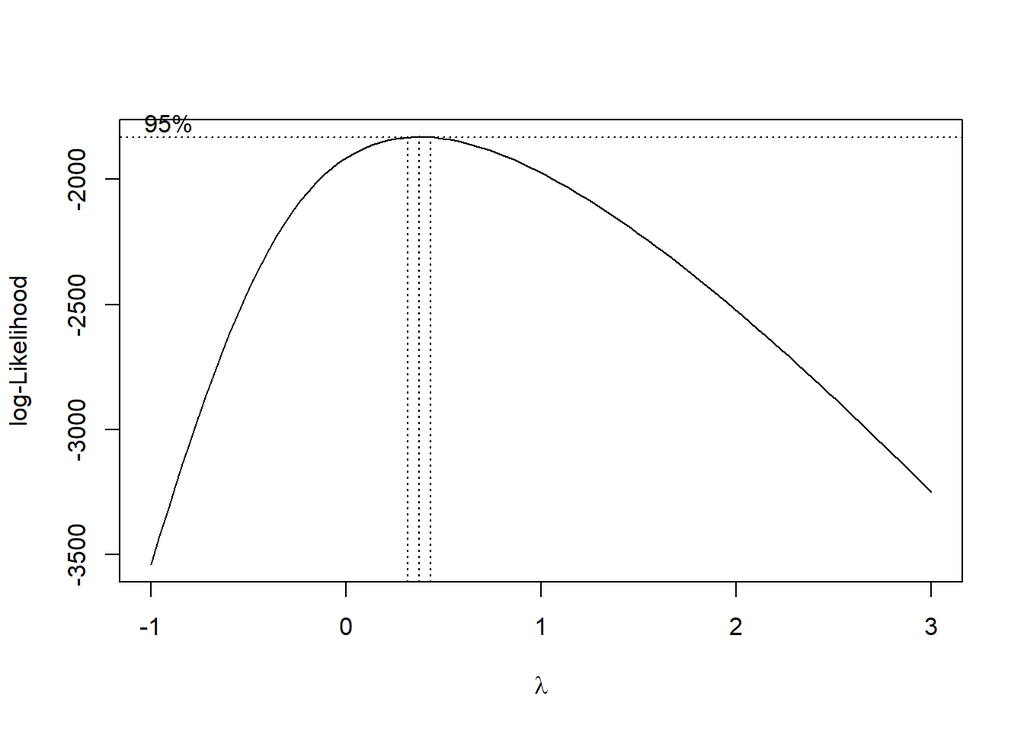

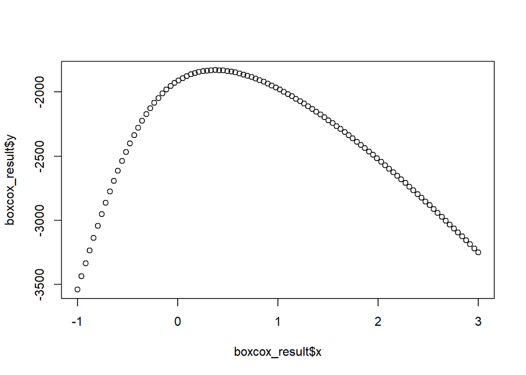

```r
# Plota o resultado
plot(boxcox_result)
```

```r
z <- max(boxcox_result$y)
lamb <- boxcox_result$x[boxcox_result$y==z]
print(lamb)
```

```
## [1] 0.3737374
```

```r
FP_ajust = (FP ^ lamb - 1) / lamb
```